# HW6_answers

# Ex 1

> Figure 8.31 shows the ACFs for 36 random numbers, 360 random numbers and 1,000 random numbers.
> 1. Explain the differences among these figures. Do they all indicate that the data are white noise?
- The figures show different critical values (blue dashed lines).
- All figures indicate that the data are white noise.
> 2. Why are the critical values at different distances from the mean of zero? Why are the autocorrelations different in each figure when they each refer to white noise?
- The critical values are at different distances from zero because the data sets have different number of observations. The more observations in a data set, the less noise appears in the correlation estimates (spikes). Therefore the critical values for bigger data sets can be smaller in order to check if the data is not white noise.

# Ex 2

> A classic example of a non-stationary series is the daily closing IBM stock price series (data set `ibmclose`). Use R to plot the daily closing prices for IBM stock and the ACF and PACF. Explain how each plot shows that the series is non-stationary and should be differenced.

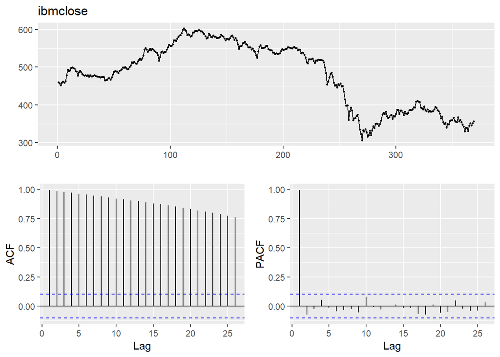

```r
ggtsdisplay(ibmclose)
```

The time plot shows the series “wandering around”, which is a typical indication of non-stationarity. Differencing the series should remove this feature.

ACF does not drop quickly to zero, moreover the value $r_1$ is large and positive (almost 1 in this case). All these are signs of a non-stationary time series. Therefore it should be differenced to obtain a stationary series.

PACF value $r_1$ is almost 1. This is a sign of a non-stationary process that should be differenced in order to obtain a stationary series.

# Ex 3

> For the following series, find an appropriate Box-Cox transformation and order of differencing in order to obtain stationary data.
> 1. `usnetelec`

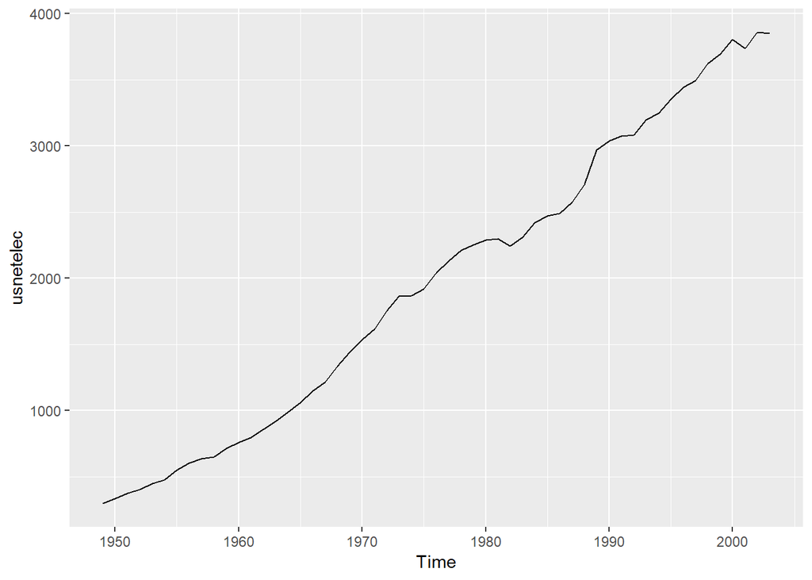

```r
autoplot(usnetelec)
```

There is no need for a Box-Cox transformation in this case.

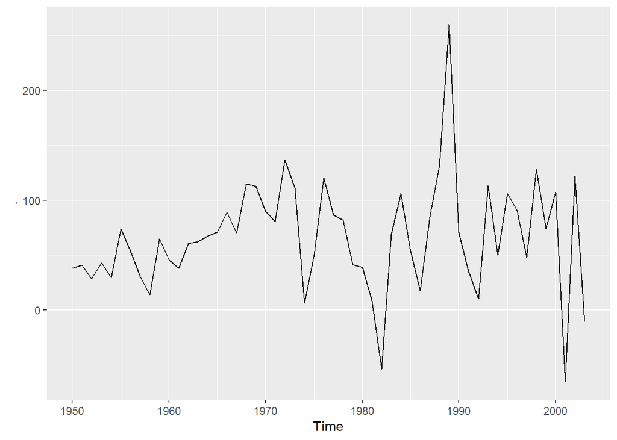

```r
usnetelec %>% diff() %>% autoplot()
```

> 2. `enplanements`

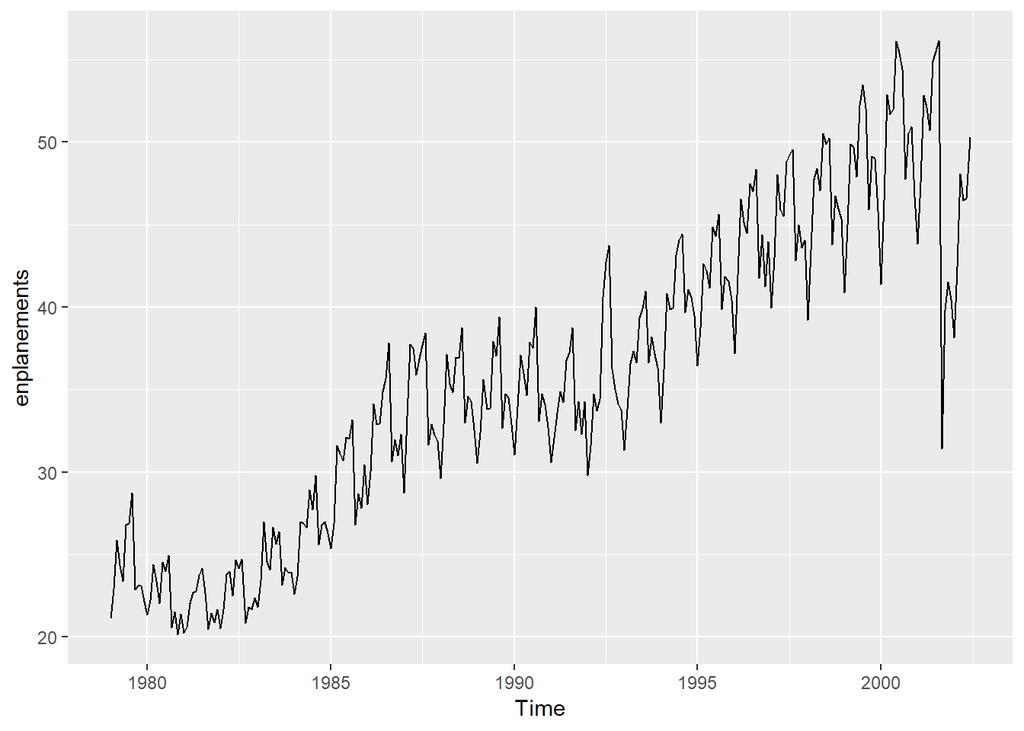

```r
autoplot(enplanements)
```

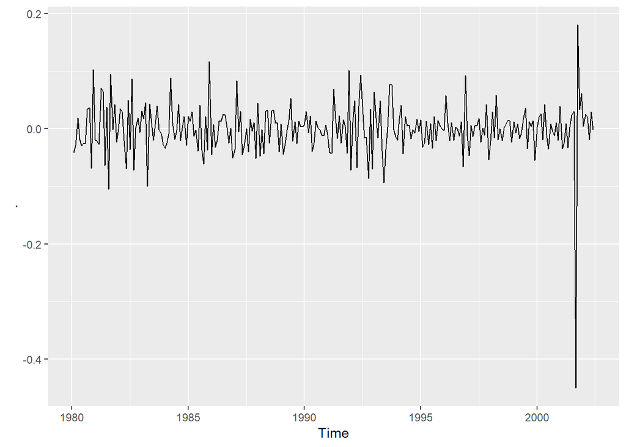

```r
enplanements %>% BoxCox(lambda=0) %>% diff(lag=12) %>% diff() %>% autoplot()
```

> 3. `visitors`

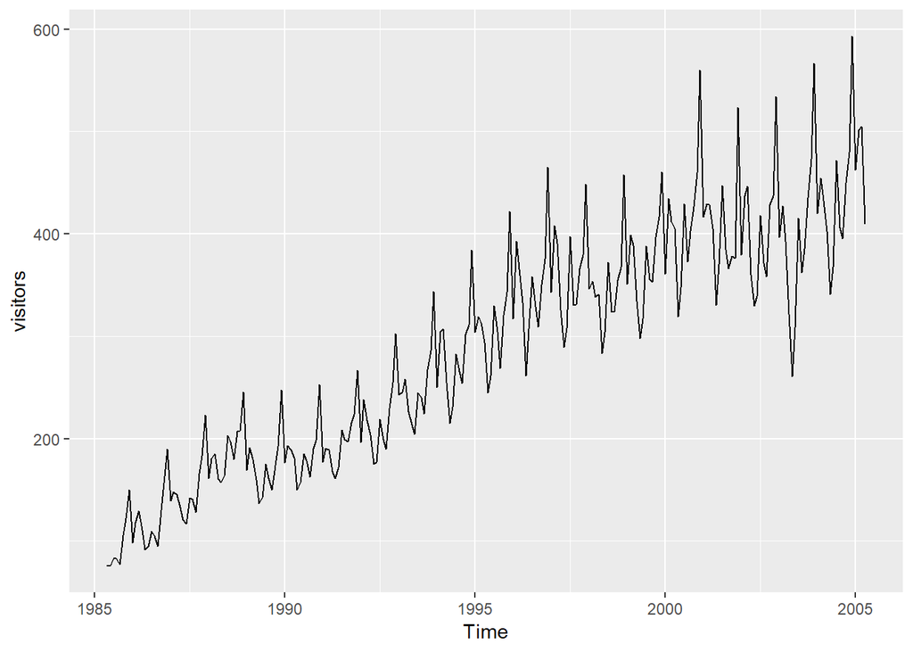

```r
autoplot(visitors)
```

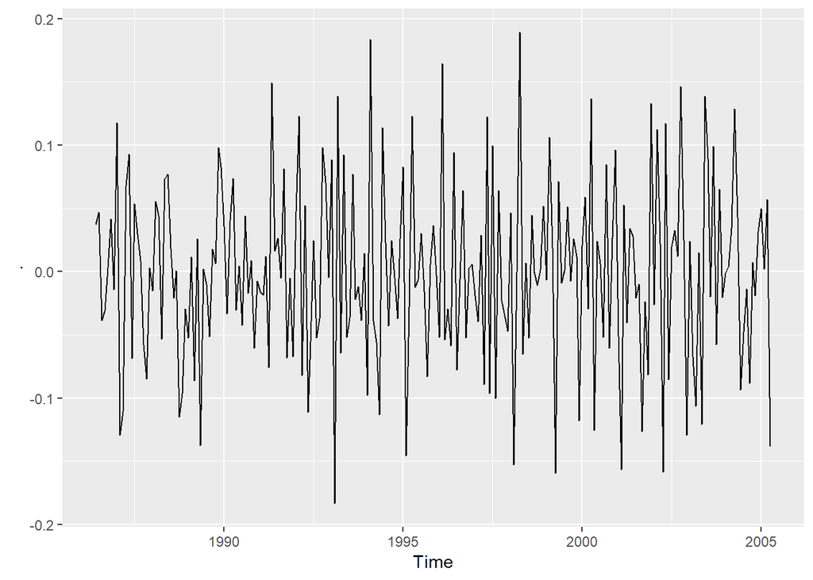

```r
visitors %>% BoxCox(lambda=0) %>% diff(lag=12) %>% diff() %>% autoplot()
```

# Ex 4

> For the `enplanements` data, write down the differences you chose above using backshift operator notation.

A seasonal (lag 12) difference, followed by a first difference:

$$(1-B) (1-B^{12})$$

# Ex 5

```r
myts <- readxl::read_excel("retail.xlsx", skip=1)[,"A3349873A"] %>%
  ts(frequency=12, start=c(1982,4))
```

First we will try logs as before, followed by a seasonal difference.

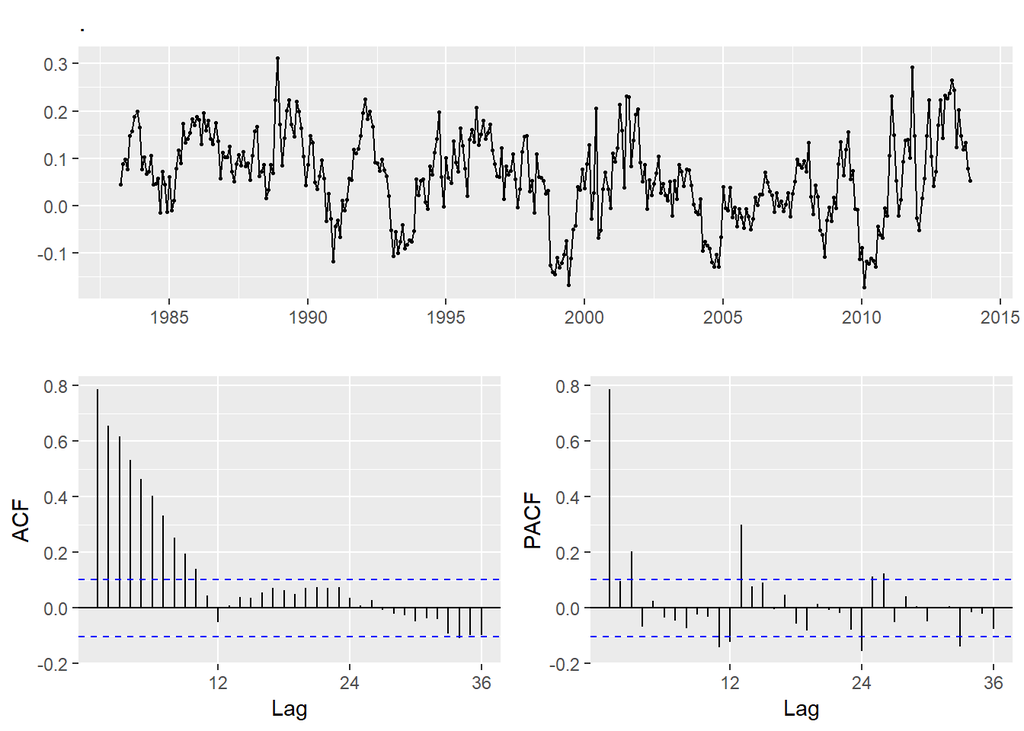

```r
myts %>% log() %>% diff(lag=12) %>% ggtsdisplay()
```

That still looks a little non-stationary, so I will take another difference at lag 1.

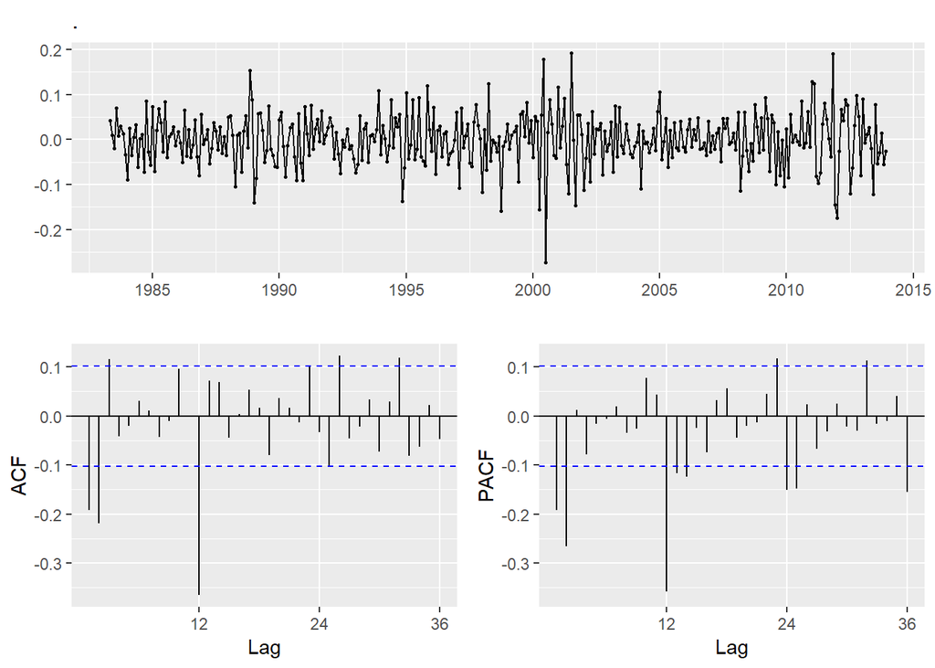

```r
myts %>% log() %>% diff(lag=12) %>% diff() %>% ggtsdisplay()
```

That looks stationary now. So we used a log, a seasonal difference, and a first difference. Other time series from retail data set may require a different set of transformation/differencing choices.

# Ex 6

> Use R to simulate and plot some data from simple ARIMA models. a. Use the following R code to generate data from an AR(1) model with $\phi_{1} = 0.6$ and $\sigma^2=1$. The process starts with $y_1=0$.

```r
ar1 <- function(phi, n=100)
{
  y <- ts(numeric(n))
  e <- rnorm(n)
  for(i in 2:n)
    y[i] <- phi*y[i-1] + e[i]
  return(y)
}
```

> 2. Produce a time plot for the series. How does the plot change as you change $\phi_1$?

Some examples of changing $\phi_1$

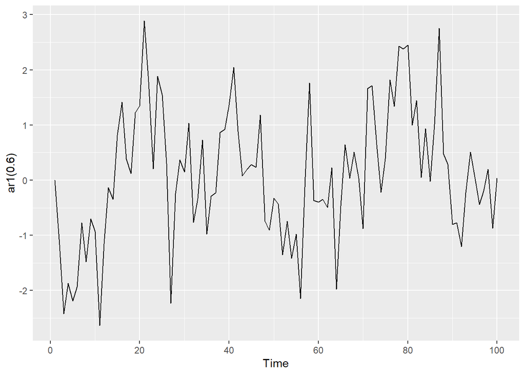

```r
autoplot(ar1(0.6))
```

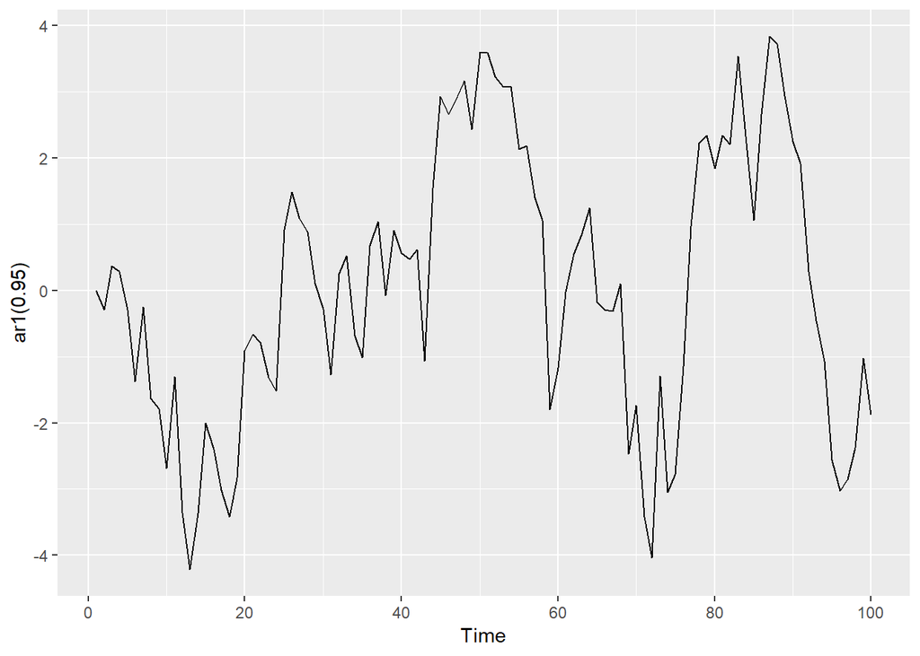

```r
autoplot(ar1(0.95))
```

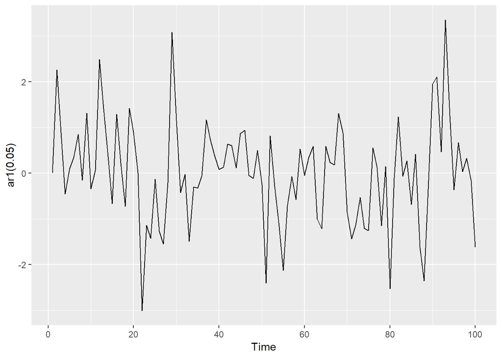

```r
autoplot(ar1(0.05))
```

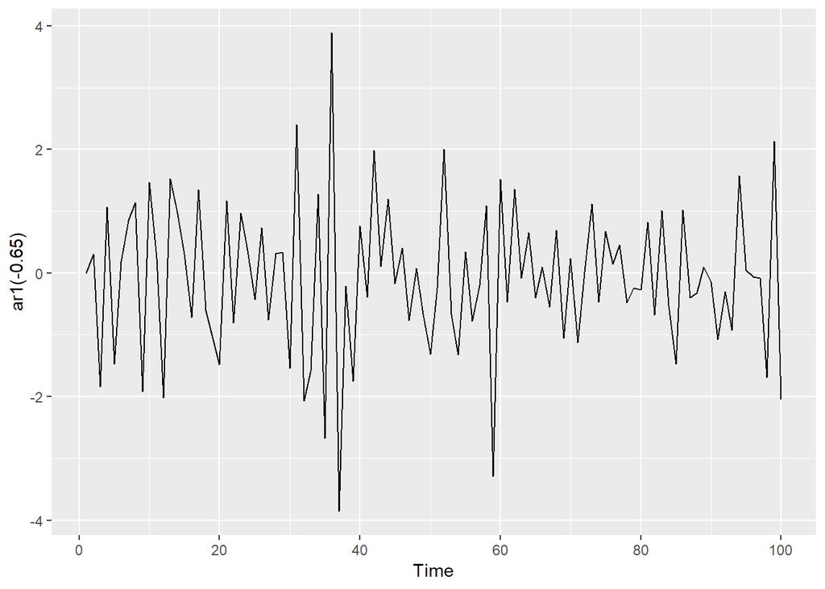

```r
autoplot(ar1(-0.65))
```

> 3. Write your own code to generate data from an MA(1) model with $\theta_{1} = 0.6$ and $\sigma^2=1$.

```r
ma1 <- function(theta, n=100)
{
  y <- ts(numeric(100))
  e <- rnorm(100)
  for(i in 2:100)
    y[i] <- theta*e[i-1] + e[i]
  return(y)
}
```

> 4. Produce a time plot for the series. How does the plot change as you change $\theta_1$?

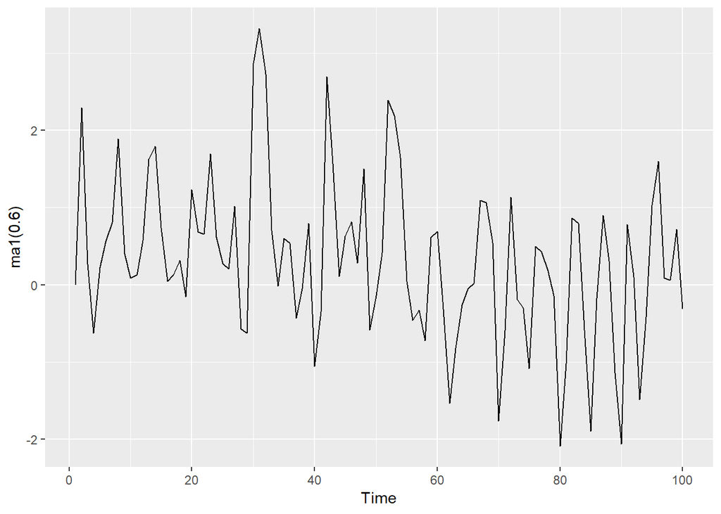

```r
autoplot(ma1(0.6))
```

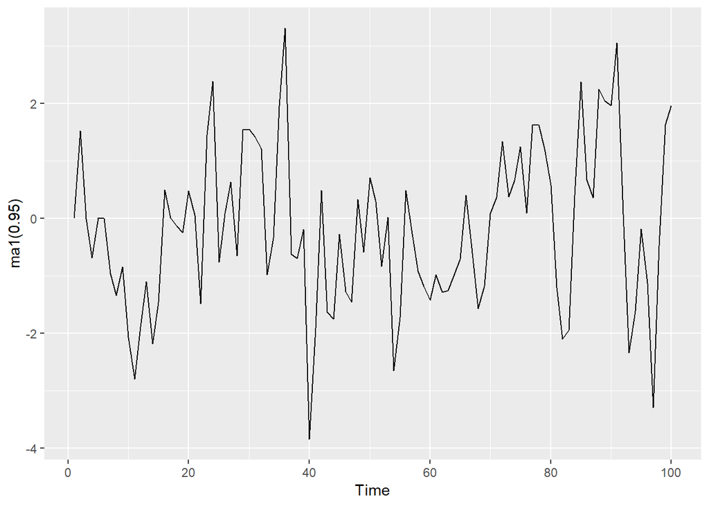

```r
autoplot(ma1(0.95))
```

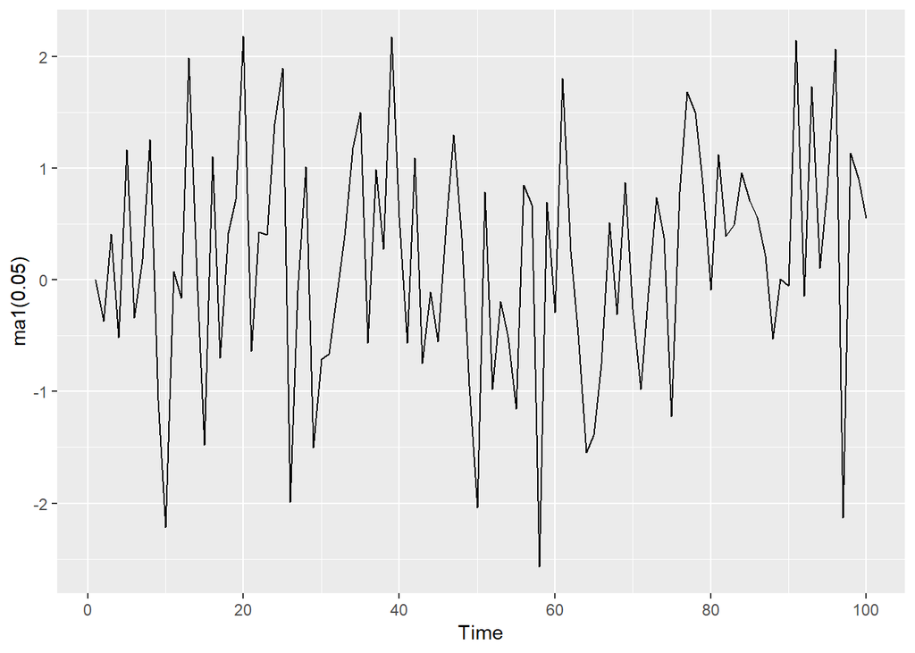

```r
autoplot(ma1(0.05))
```

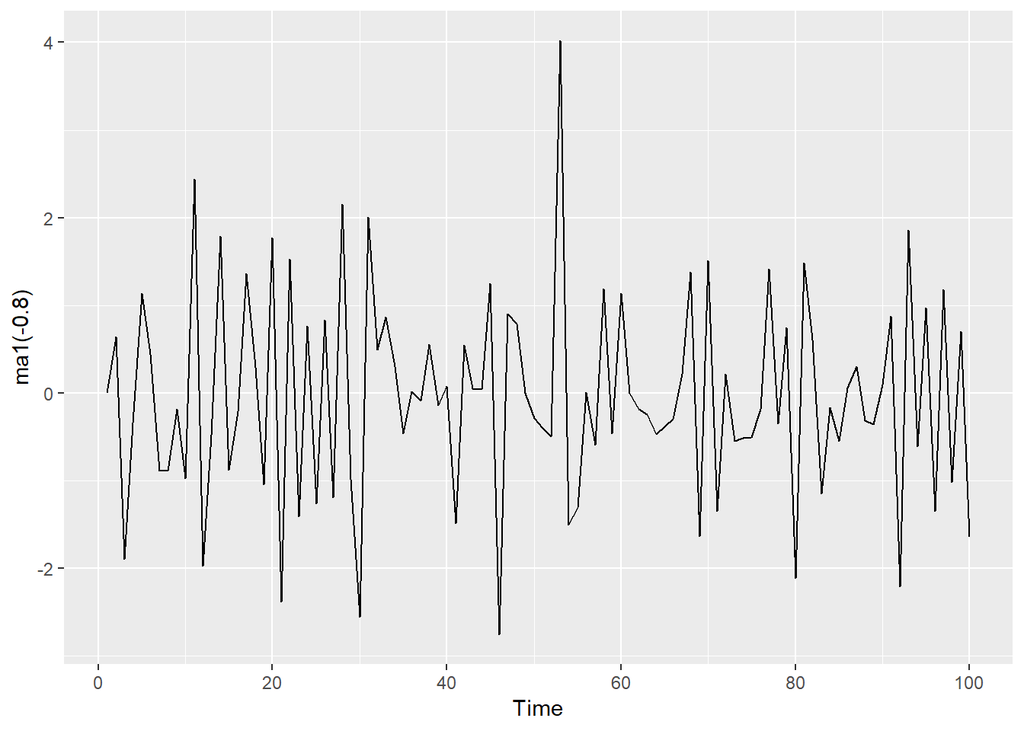

```r
autoplot(ma1(-0.8))
```

> 5. Generate data from an ARMA(1,1) model with $\phi_{1} = 0.6$, $\theta_{1} = 0.6$ and $\sigma^2=1$.

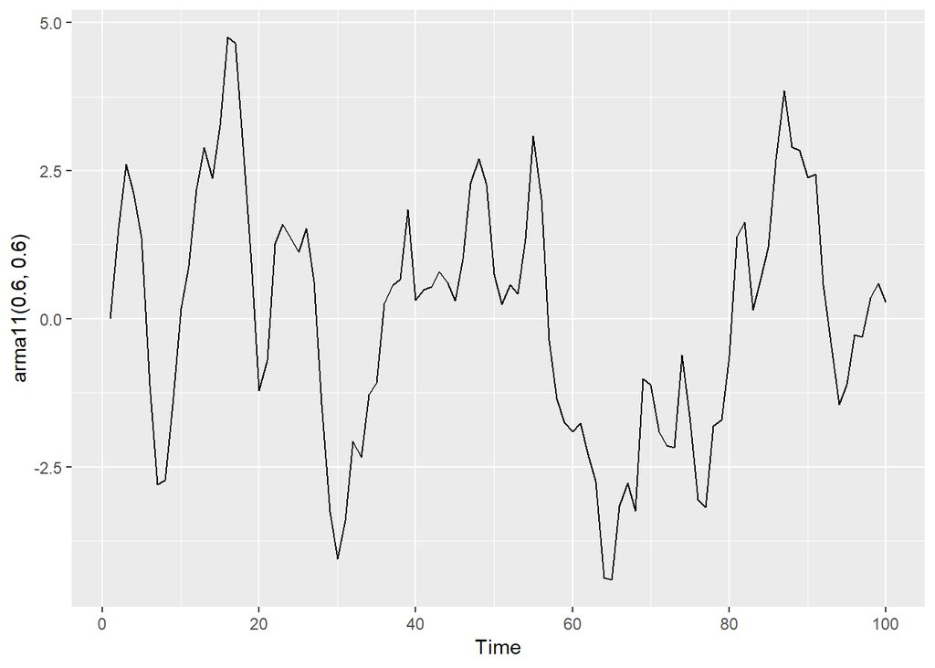

```r
arma11 <- function(phi, theta, n=100)
{
  y <- ts(numeric(100))
  e <- rnorm(100)
  for(i in 2:100)
    y[i] <- phi*y[i-1] + theta*e[i-1] + e[i]
  return(y)
}
autoplot(arma11(0.6,0.6))
```

> 6. Generate data from an AR(2) model with $\phi_{1} =-0.8$, $\phi_{2} = 0.3$ and $\sigma^2=1$. (Note that these parameters will give a non-stationary series.)

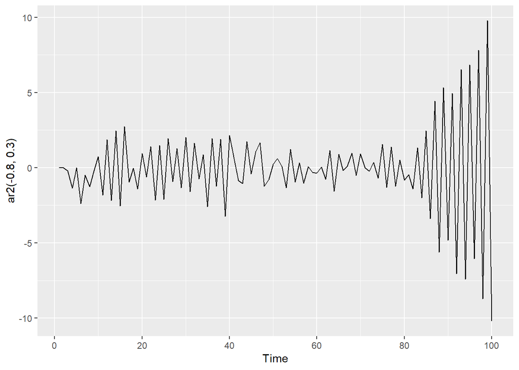

```r
ar2 <- function(phi1, phi2, n=100)
{
  y <- ts(numeric(100))
  e <- rnorm(100)
  for(i in 3:100)
    y[i] <- phi1*y[i-1] + phi2*y[i-2] + e[i]
  return(y)
}
autoplot(ar2(-0.8,0.3))
```

> 7. Graph the latter two series and compare them.

See graphs above. The non-stationarity of the AR(2) process has led to increasing oscillations

# Ex 7

> Consider `wmurders`, the number of women murdered each year (per 100,000 standard population) in the United States.
> 1. By studying appropriate graphs of the series in R, find an appropriate ARIMA($p,d,q$) model for these data.

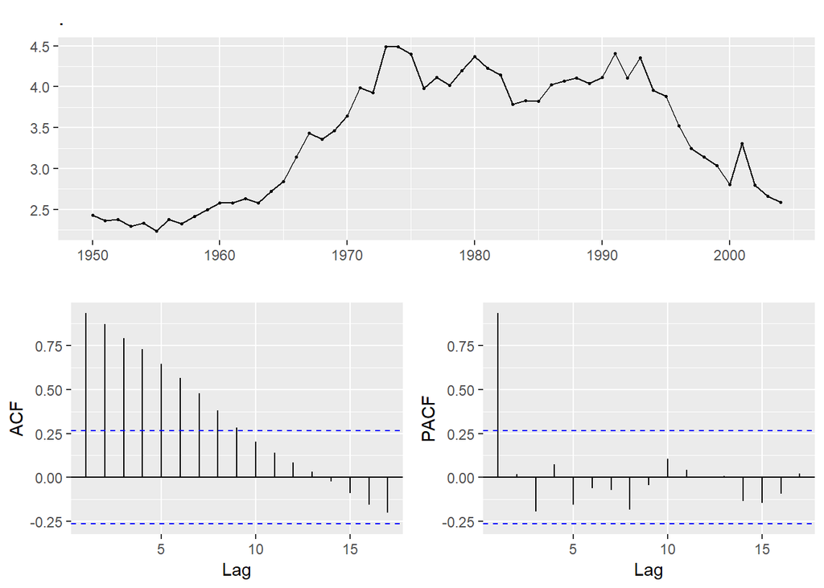

```r
wmurders %>% ggtsdisplay()
```

The graphs suggest differencing of the data before applying ARMA models.

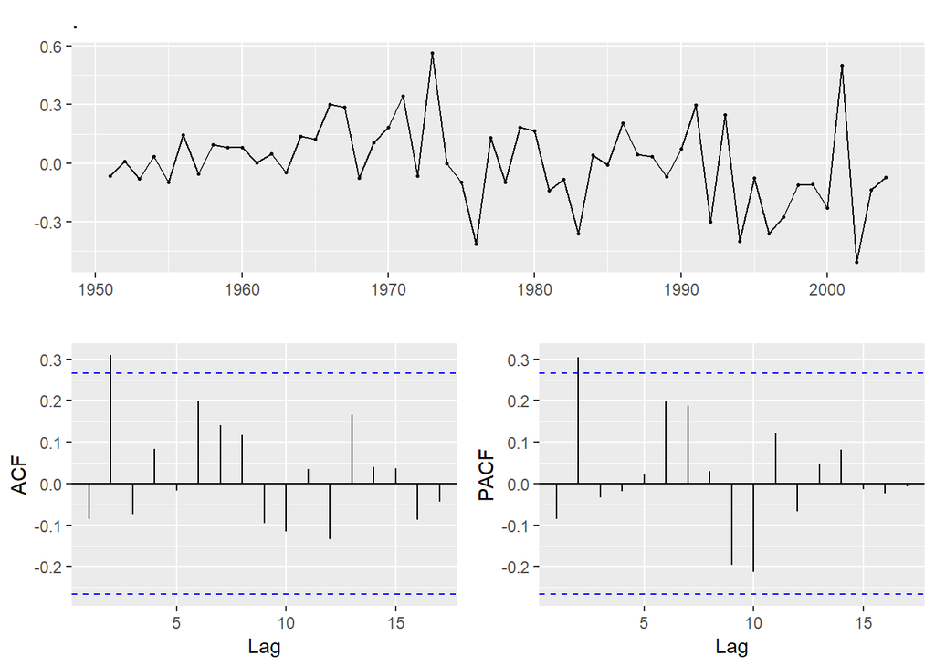

```r
wmurders %>% diff() %>% ggtsdisplay()
```

The ACF and PACF graphs suggest that the resulting time series might be an AR(2) or MA(2) due to the significant spike at lag 2 in both graphs. So either an ARIMA(0,1,2) or an ARIMA(2,1,0) appear appropriate. As we need to make a choice, I’ll use an ARIMA(0,1,2) in what follows.

> 2. Should you include a constant in the model? Explain.

A constant would imply a drift in the original data which does not look correct, so we omit the constant.

> 3. Write this model in terms of the backshift operator.

ARIMA(0,1,2): $(1-B)y_t = (1 + \theta_1B + \theta_2B^2) \varepsilon_{t}$.

> 4. Fit the model using R and examine the residuals. Is the model satisfactory?

```r
(fit <- Arima(wmurders, c(0,1,2)))
```

```
## Series: wmurders
## ARIMA(0,1,2)
##
## Coefficients:
##          ma1    ma2
##       -0.066  0.371
## s.e.   0.126  0.164
##
## sigma^2 estimated as 0.0422:  log likelihood=9.71
## AIC=-13.43   AICc=-12.95   BIC=-7.46
```

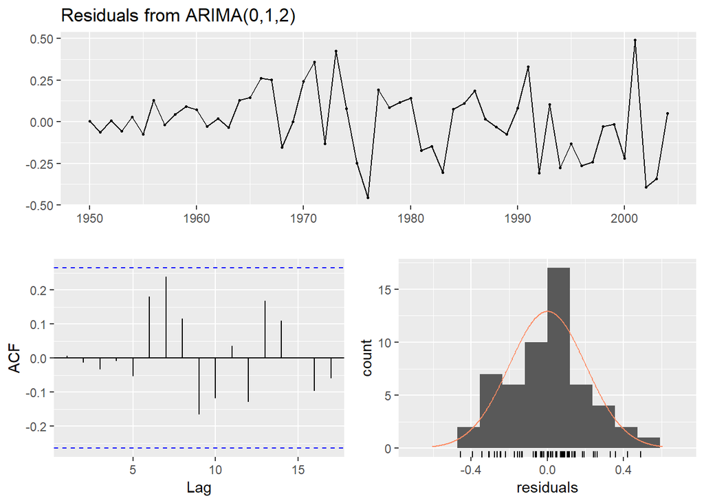

```
##
##  Ljung-Box test
##
## data:  Residuals from ARIMA(0,1,2)
## Q* = 9.77, df = 8, p-value = 0.28
##
## Model df: 2.   Total lags used: 10
```

```r
checkresiduals(fit)
```

- No obvious patterns are visible on the graph of the residuals
- Ljung-Box test suggests that the residuals are white noise
- The residuals look close enough to normally distributed

The model is satisfactory.

> 5. Forecast three times ahead. Check your forecasts by hand to make sure that you know how they have been calculated.

```r
(fcast <- forecast(fit, h = 3))
```

```
##      Point Forecast  Lo 80  Hi 80  Lo 95  Hi 95
## 2005         2.4585 2.1952 2.7217 2.0558 2.8611
## 2006         2.4771 2.1169 2.8373 1.9262 3.0280
## 2007         2.4771 1.9793 2.9749 1.7157 3.2385
```

To check the forecasts by hand we use the model written in terms of the backshift operator:

$$(1-B)y_t = (1 + \theta_1B + \theta_2B^2) \varepsilon_{t},$$
where $y_t$ is the observed time series and the coefficients are $\theta_1 = -0.066$ and $\theta_2 = 0.371$. It can be rewritten as:
$$y_t = y_{t-1} + \varepsilon_t -0.066\varepsilon_{t-1} + 0.371\varepsilon_{t-2}.$$
The last observation is 2.5894 and the last few residuals are -0.39266, -0.34376, 0.05024. So the next forecast is:
$$\hat{y}_{T+1|T} = 2.5894 + 0
-0.066 (0.0502) +
0.371 (-0.3438) = 2.4585.$$
Similarly,
$$\hat{y}_{T+2|T} = 2.4585 + 0 + 0 +
0.371 (0.0502) = 2.4771$$
and
$$\hat{y}_{T+3|T} = 2.4771 + 0 + 0 + 0 = 2.4771.$$

> 6. Create a plot of the series with forecasts and prediction intervals for the next three periods shown.

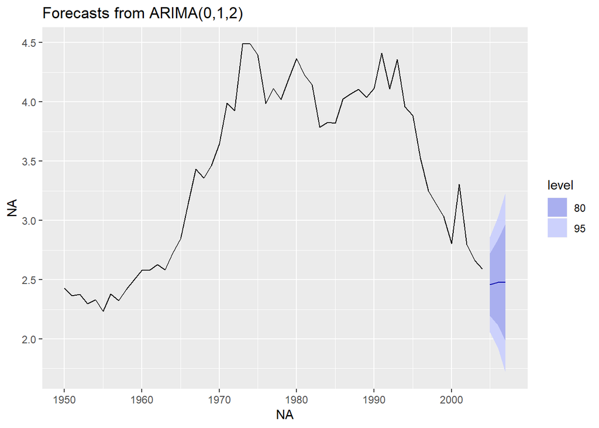

```r
autoplot(fcast)
```

> 7. Does `auto.arima` give the same model you have chosen? If not, which model do you think is better?

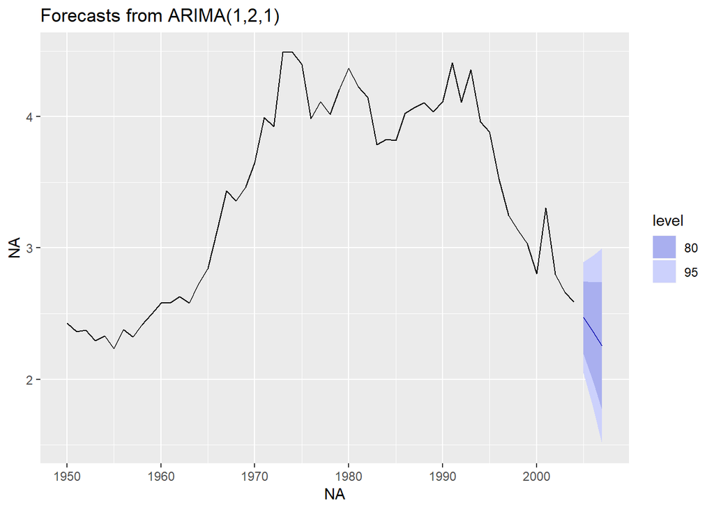

```r
fit.auto <- auto.arima(wmurders)
fcast.auto <- forecast(fit.auto, h = 3)
autoplot(fcast.auto)
```

`auto.arima` picked a more complex model which assumes that the trend in the data will continue in the future. The extra level of differencing is hard to justify from the graphs, and it is unlikely that murder rates will fall indefinitely. So I’d probably prefer only one difference. We can force `auto.arima` to do that:

```r
(fit.auto = auto.arima(wmurders, d=1, stepwise=FALSE))
```

```
## Series: wmurders
## ARIMA(0,1,2)
##
## Coefficients:
##          ma1    ma2
##       -0.066  0.371
## s.e.   0.126  0.164
##
## sigma^2 estimated as 0.0422:  log likelihood=9.71
## AIC=-13.43   AICc=-12.95   BIC=-7.46
```

Now `auto.arima` picks the same model that I did.

# Ex 8

> Consider `austa`, the total international visitors to Australia (in millions) for the period 1980-2015.
> 1. Use `auto.arima()` to find an appropriate ARIMA model. What model was selected. Check that the residuals look like white noise. Plot forecasts for the next 10 periods.

```r
(fit <- auto.arima(austa))
```

```
## Series: austa
## ARIMA(0,1,1) with drift
##
## Coefficients:
##         ma1  drift
##       0.301  0.173
## s.e.  0.165  0.039
##
## sigma^2 estimated as 0.0338:  log likelihood=10.62
## AIC=-15.24   AICc=-14.46   BIC=-10.57
```

An ARIMA(0,1,1) with drift model is selected .

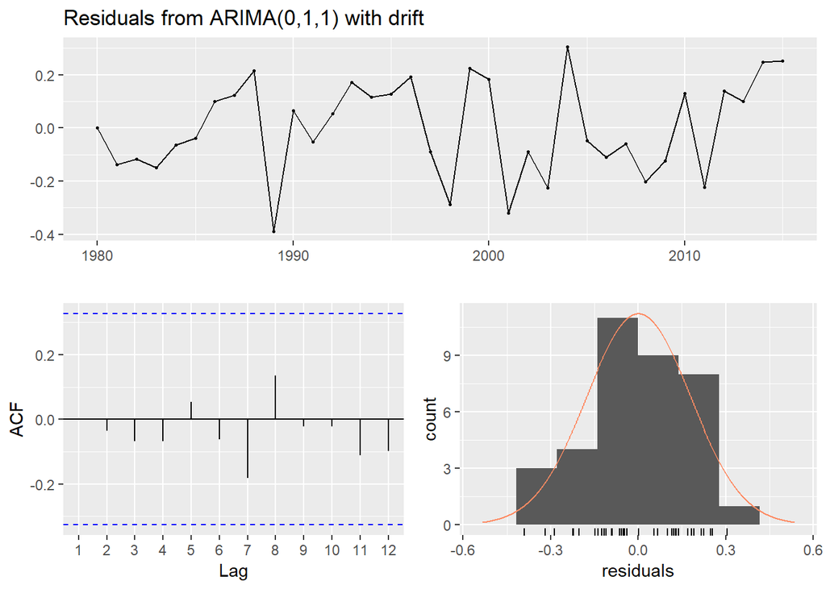

```
##
##  Ljung-Box test
##
## data:  Residuals from ARIMA(0,1,1) with drift
## Q* = 2.3, df = 5.2, p-value = 0.83
##
## Model df: 2.   Total lags used: 7.2
```

```r
checkresiduals(fit)
```

The residuals look like white noise.

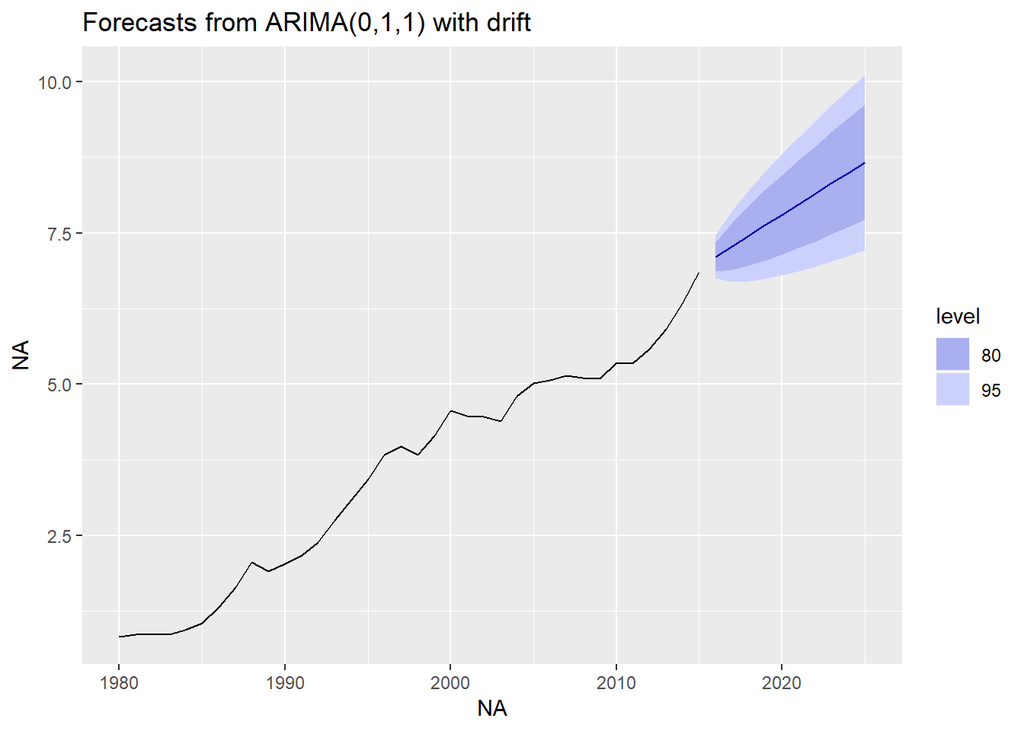

```r
fit %>% forecast(h=10) %>% autoplot()
```

> 2. Plot forecasts from an ARIMA(0,1,1) model with no drift and compare these to part a. Remove the MA term and plot again.

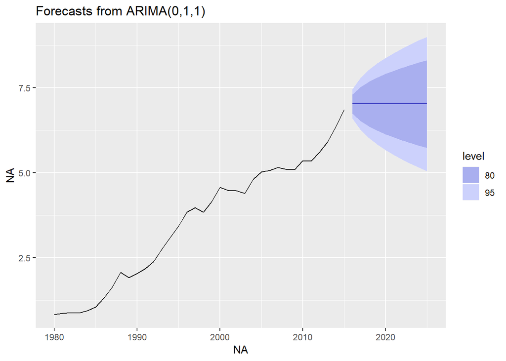

```r
austa %>% Arima(order=c(0,1,1), include.constant=FALSE) %>%
  forecast() %>% autoplot()
```

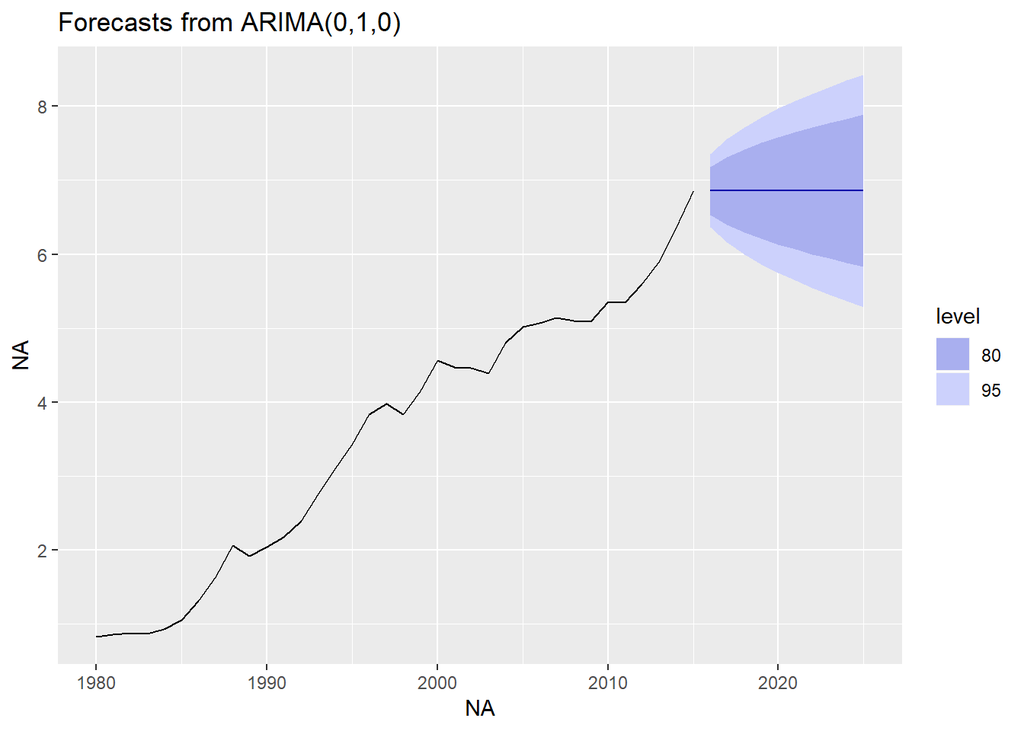

```r
austa %>% Arima(order=c(0,1,0), include.constant=FALSE) %>%
  forecast() %>% autoplot()
```

Removing the drift term makes a big difference as the forecasts no longer have a linear trend. Removing the MA(1) term makes almost no difference.

> 3. Plot forecasts from an ARIMA(2,1,3) model with drift. Remove the constant and see what happens.

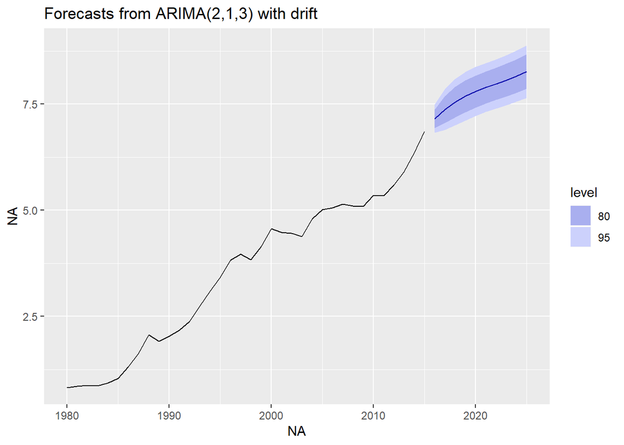

```r
austa %>% Arima(order=c(2,1,3), include.constant=TRUE) %>%
  forecast() %>% autoplot()
```

```r
austa %>% Arima(order=c(2,1,3), include.constant=FALSE) %>%
  forecast() %>% autoplot()
```

```
Error in stats::arima(x = x, order = order, seasonal = seasonal, include.mean = include.mean,  :
  non-stationary AR part from CSS
```

The model fitting causes an error because the drift is really needed. What happens is that the AR terms try to handle the drift but end up going outside the stationarity region.

> 4. Plot forecasts from an ARIMA(0,0,1) model with a constant. Remove the MA term and plot again.

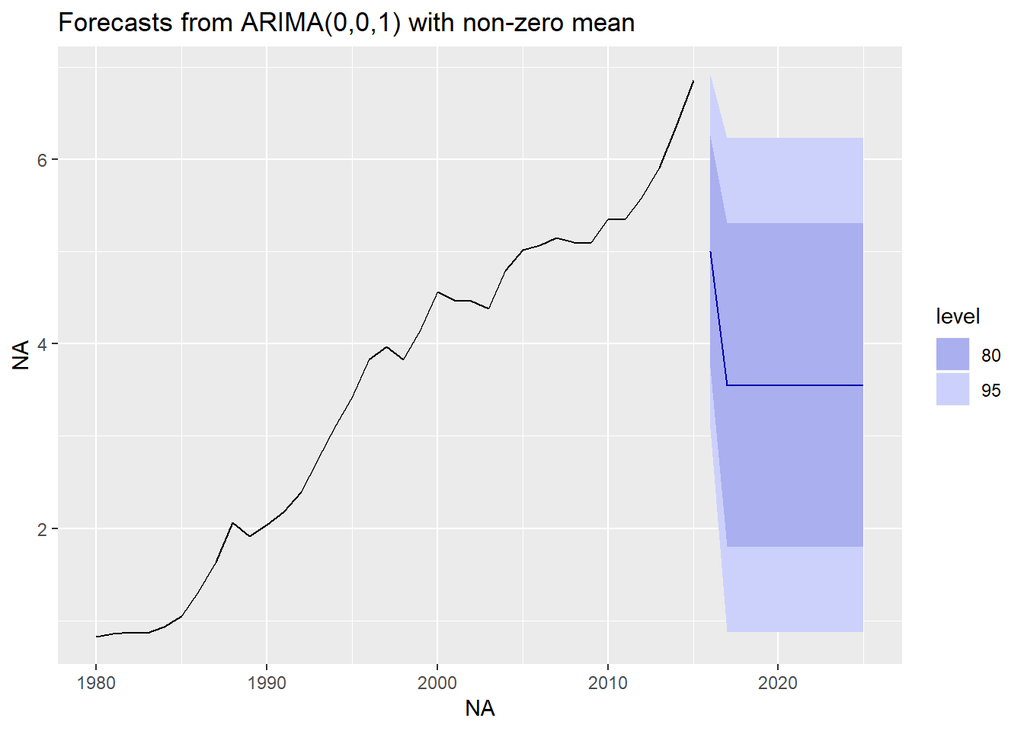

```r
austa %>% Arima(order=c(0,0,1), include.constant=TRUE) %>%
  forecast() %>% autoplot()
```

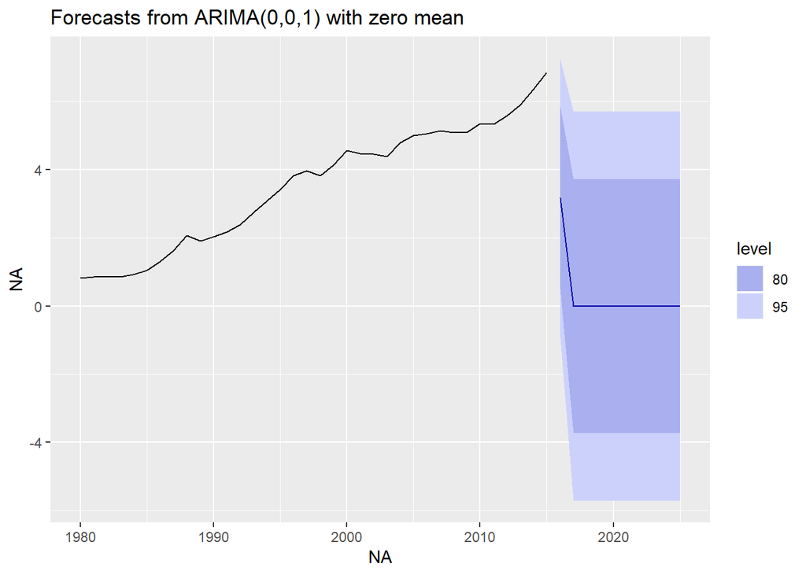

```r
austa %>% Arima(order=c(0,0,1), include.constant=FALSE) %>%
  forecast() %>% autoplot()
```

A stationary model with a constant has long term forecasts equal to the mean (long term here meaning after the first horizon). A stationary model without a constant has long term forecasts equal to zero.

> 5. Plot forecasts from an ARIMA(0,2,1) model with no constant.

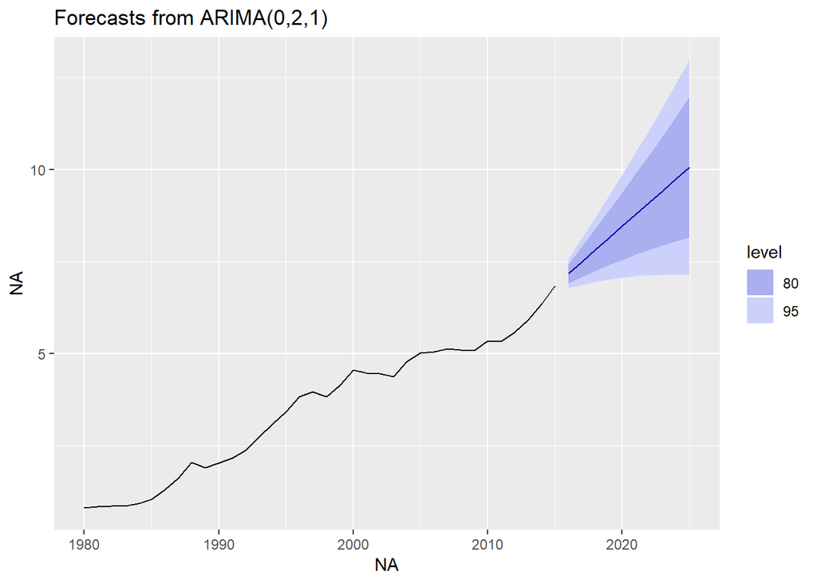

```r
austa %>% Arima(order=c(0,2,1), include.constant=FALSE) %>%
  forecast() %>% autoplot()
```

The second level of differencing induces a linear trend in the forecasts, but the prediction intervals become quite wide.